# Assignment

feifei fu

1/27/2022

```r
library(tidyverse)
```

### a)

The data values are separated one from the next by the method *“read_table()”*. Because the data has two columns: “university” and “weight”. One contains character values and the other contains numerical values. And this two columns are separated by a space.

### b)

```r
url <- "https://ritsokiguess.site/datafiles/boat_race.txt"
rower <- read_table(url)
head(rower) #display 6 rows
```

```
## # A tibble: 6 × 2
##   university weight
##   <chr>       <dbl>
## 1 Oxford       186
## 2 Cambridge    188.
## 3 Oxford       184.
## 4 Cambridge    183
## 5 Oxford       204
## 6 Cambridge    184.
```

### c)

The plot I choose is **side_by_side box plot**.

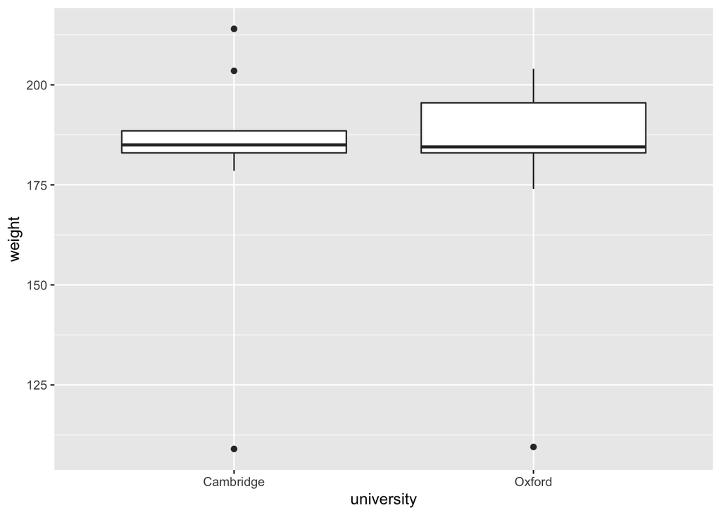

```r
ggplot(rower, aes(x=university,y=weight)) +geom_boxplot()
```

### d)

The average weights of the rowers on the two teams are similar. because the plot shows that the median of the weight is very similar between the two universities. From the median, we can assume that Mean is also very similar.

### e)

**similarity**: There is a very, very light value of weight in the weight distribution of both rowing teams, while the rest eight value of weight distribution is relatively concentrated.

### f)

The lightest weight in both group is the cox. In the data of Oxford is 109.5 and in the data of Cambridge is 109. Because the cox does not need to row, there is no demand on strength, and therefore does not need to be too heavy. Instead, the cox needs a lighter weight to make the overall weight of the ship lighter and easier to move. Statistically, the eight rowers should be very similar in weight, and the only one that was significantly lower than average should have had a different meaning, cox.